# FIRE Campus Speech Analysis - 2026

DGK

Q3 2025

# 1. Setup and Data Loading

## 1.1 Load Required Libraries

```r
library(tidyverse)
library(ggplot2)
library(corrplot)
library(car)
library(dplyr)
library(readr)
library(haven)
library(forcats)
library(scales)
```

# 1.2 Load 2026 Dataset

```r
# Load the 2026 numeric dataset

FILEPATH <- "/Users/dgkamper/Library/CloudStorage/GoogleDrive-dgkamper@gmail.com/My Drive/DGK Lab/Collaborations/Haselton Lab/DGK Lab; Haselton Lab - FIRE Dataset Analysis/Data/cfsrALL.csv"

df_2026 <- read.csv(FILEPATH, na.strings = c("", "NA", "-99", "98", "99"), stringsAsFactors = TRUE)

# Replace this with actual data loading:
cat("2026 Dataset dimensions:", dim(df_2026), "\n")
```

```
## 2026 Dataset dimensions: 284372 178
```

```r
cat("Number of variables:", ncol(df_2026), "\n")
```

```
## Number of variables: 178
```

```r
cat("Number of observations:", nrow(df_2026), "\n")
```

```
## Number of observations: 284372
```

```r
# Expected output based on codebook:
cat("Expected 2026 Dataset dimensions: 284,372 rows x 178 columns\n")
```

```
## Expected 2026 Dataset dimensions: 284,372 rows x 178 columns
```

# 2. Data Preprocessing

## 2.1 Variable Creation and Cleaning Function

```r
# Function to convert variables to numeric while preserving order
convert_to_numeric_ordered <- function(x, reverse = FALSE) {
  if(is.factor(x) || is.labelled(x)) {
    if(is.labelled(x)) {
      numeric_values <- as.numeric(x)
    } else {
      numeric_values <- as.numeric(x)
    }

    if(reverse) {
      max_val <- max(numeric_values, na.rm = TRUE)
      numeric_values <- (max_val + 1) - numeric_values
    }
    return(numeric_values)
  } else {
    return(as.numeric(x))
  }
}

# Main data processing function using actual variable names
process_fire_2026_data <- function(df) {
  cat("Processing 2026 FIRE dataset with correct variable structure...\n")

  df_analysis <- df

  # ============================================================================
  # SELF-CENSORSHIP VARIABLES (Actual names: sc, sc_stdnt, sc_profs, sc_class)
  # ============================================================================

  selfcensor_vars <- c("sc", "sc_stdnt", "sc_profs", "sc_class")
  selfcensor_names <- c("General Self-Censorship", "With Students", "With Professors", "In Classroom")

  for(i in 1:length(selfcensor_vars)) {
    var <- selfcensor_vars[i]
    if(var %in% names(df_analysis)) {
      df_analysis[[paste0(var, "_num")]] <- convert_to_numeric_ordered(df_analysis[[var]])
    }
  }

  # ============================================================================
  # COMFORT EXPRESSING VIEWS (Actual names: cf_*)
  # ============================================================================

  comfort_vars <- c("cf_pubprof", "cf_socmedia", "cf_inclass", "cf_wrtprof", "cf_quad")
  comfort_names <- c("Public Prof Disagreement", "Social Media", "In-Class", "Written Prof", "Campus Common Areas")

  for(var in comfort_vars) {
    if(var %in% names(df_analysis)) {
      df_analysis[[paste0(var, "_num")]] <- convert_to_numeric_ordered(df_analysis[[var]])
    }
  }

  # ============================================================================
  # PROTEST TOLERANCE (Actual names: act_shout, act_block, act_viol)
  # ============================================================================

  protest_vars <- c("act_shout", "act_block", "act_viol")
  protest_names <- c("Shouting Down", "Blocking Access", "Violence Against Speakers")

  for(var in protest_vars) {
    if(var %in% names(df_analysis)) {
      df_analysis[[paste0(var, "_num")]] <- convert_to_numeric_ordered(df_analysis[[var]])
    }
  }

  # ============================================================================
  # SPEAKER TOLERANCE (Actual names: spk_*) - CORRECTED REGEX
  # ============================================================================

  speaker_vars <- grep("^spk_", names(df_analysis), value = TRUE)
  for(var in speaker_vars) {
    if(var %in% names(df_analysis)) {
      df_analysis[[paste0(var, "_num")]] <- convert_to_numeric_ordered(df_analysis[[var]])
    }
  }

  # ============================================================================
  # IDEOLOGY AND POLITICAL VARIABLES
  # ============================================================================

  if("ideo" %in% names(df_analysis)) {
    df_analysis$ideology_clean <- factor(df_analysis$ideo, ordered = TRUE,
                                        levels = 1:11,
                                        labels = c("Very liberal", "Somewhat liberal", "Slightly liberal",
                                                  "Moderate", "Slightly conservative", "Somewhat conservative",
                                                  "Very conservative", "Democratic Socialist", "Libertarian",
                                                  "Haven't thought about this", "Something else"))
  }

  if("cp_partyid" %in% names(df_analysis)) {
    df_analysis$party_clean <- factor(df_analysis$cp_partyid)
  }

  if("issueimportance" %in% names(df_analysis)) {
    df_analysis$issue_importance <- factor(df_analysis$issueimportance,
                                          levels = 1:10,
                                          labels = c("Abortion/Reproductive Health", "Cost of Education", "Immigration", "Gun Policy",
                                                    "Racial Inequality", "LGBTQ Treatment", "Income Inequality",
                                                    "Environment/Climate", "Foreign Policy", "Other"))
  }

  # ============================================================================
  # MENTAL HEALTH VARIABLES (Actual names: mh_*)
  # ============================================================================

  mh_vars <- c("mh_anxious", "mh_lonely", "mh_depressed", "mh_stressed")
  for(var in mh_vars) {
    if(var %in% names(df_analysis)) {
      df_analysis[[paste0(var, "_num")]] <- convert_to_numeric_ordered(df_analysis[[var]])
    }
  }

  # ============================================================================
  # TOPIC DIFFICULTY VARIABLES (Actual names: tk_*) - CORRECTED REGEX
  # ============================================================================

  topic_vars <- grep("^tk_", names(df_analysis), value = TRUE)

  # Create topic name mapping
  topic_labels <- list(
    "tk_abortion" = "Abortion",
    "tk_climate" = "Climate Change",
    "tk_police" = "Police",
    "tk_religion" = "Religion",
    "tk_raceineq" = "Racial Inequality",
    "tk_trans" = "Transgender Issues",
    "tk_ipc" = "Israel/Palestine",
    "tk_immig" = "Immigration",
    "tk_gunctrl" = "Gun Control",
    "tk_freespeech" = "Free Speech",
    "tk_affirmact" = "Affirmative Action",
    "tk_sexasslt" = "Sexual Assault"
  )

  for(var in topic_vars) {
    if(var %in% names(df_analysis)) {
      df_analysis[[paste0(var, "_difficult")]] <- factor(df_analysis[[var]],
                                                         levels = c(0, 1),
                                                         labels = c("Not Difficult", "Difficult"))
    }
  }

  # ============================================================================
  # GROUP FUNDING VARIABLES (Actual names: grp_*) - CORRECTED REGEX
  # ============================================================================

  group_vars <- grep("^grp_", names(df_analysis), value = TRUE)
  for(var in group_vars) {
    if(var %in% names(df_analysis)) {
      df_analysis[[paste0(var, "_support")]] <- factor(df_analysis[[var]],
                                                       levels = c(0, 1),
                                                       labels = c("No", "Yes"))
    }
  }

  # ============================================================================
  # POLICY PREFERENCES (Actual names: plcy_*) - CORRECTED REGEX
  # ============================================================================

  policy_vars <- grep("^plcy_", names(df_analysis), value = TRUE)
  for(var in policy_vars) {
    if(var %in% names(df_analysis)) {
      df_analysis[[paste0(var, "_support")]] <- factor(df_analysis[[var]],
                                                       levels = c(0, 1),
                                                       labels = c("No", "Yes"))
    }
  }

  # ============================================================================
  # DEMOGRAPHIC VARIABLES
  # ============================================================================

  demo_vars <- c("race", "gender_bin", "gradyear", "religion", "ses")
  for(var in demo_vars) {
    if(var %in% names(df_analysis)) {
      df_analysis[[paste0(var, "_clean")]] <- factor(df_analysis[[var]])
    }
  }

  # ============================================================================
  # INSTITUTIONAL VARIABLES
  # ============================================================================

  if("adminclear" %in% names(df_analysis)) {
    df_analysis$admin_clear_num <- convert_to_numeric_ordered(df_analysis$adminclear)
  }
  if("admincontr" %in% names(df_analysis)) {
    df_analysis$admin_defend_num <- convert_to_numeric_ordered(df_analysis$admincontr)
  }

  cat("2026 FIRE data processing complete!\n")
  cat("Variables found and processed:\n")
  cat("- Self-censorship measures:", sum(selfcensor_vars %in% names(df_analysis)), "of", length(selfcensor_vars), "\n")
  cat("- Comfort expressing views:", sum(comfort_vars %in% names(df_analysis)), "of", length(comfort_vars), "\n")
  cat("- Protest tolerance:", sum(protest_vars %in% names(df)), "of", length(protest_vars), "\n")
  cat("- Topic difficulty variables:", length(topic_vars), "\n")
  cat("- Speaker tolerance variables:", length(speaker_vars), "\n")
  cat("- Group funding variables:", length(group_vars), "\n")
  cat("- Policy preference variables:", length(policy_vars), "\n\n")

  return(df_analysis)
}
```

# 3. Core Self Censorship Analysis: Individual Correlations

```r
analyze_core_correlations <- function(df_analysis) {
  cat("=== CORE ANALYSIS: SELF-CENSORSHIP VS PROTEST TOLERANCE ===\n\n")
  cat("Research Question: How do self-censorship behaviors relate to tolerance for protest tactics?\n\n")

  # Define variables with actual names
  selfcensor_vars <- c("sc_num", "sc_stdnt_num", "sc_profs_num", "sc_class_num",
                      "cf_pubprof_num", "cf_socmedia_num", "cf_inclass_num",
                      "cf_wrtprof_num", "cf_quad_num")

  selfcensor_labels <- c("General Self-Censorship", "With Students", "With Professors", "In Classroom",
                        "Public Prof Disagreement", "Social Media", "In-Class Discussion",
                        "Written Prof Disagreement", "Campus Common Areas")

  protest_vars <- c("act_shout_num", "act_block_num", "act_viol_num")
  protest_labels <- c("Shouting Down", "Blocking Access", "Violence")

  # Calculate correlations
  correlation_results <- data.frame()

  for(i in 1:length(selfcensor_vars)) {
    for(j in 1:length(protest_vars)) {
      sc_var <- selfcensor_vars[i]
      pt_var <- protest_vars[j]

      if(sc_var %in% names(df_analysis) && pt_var %in% names(df_analysis)) {
        complete_data <- df_analysis[!is.na(df_analysis[[sc_var]]) & !is.na(df_analysis[[pt_var]]), ]

        if(nrow(complete_data) > 100) {
          cor_test <- cor.test(complete_data[[sc_var]], complete_data[[pt_var]])

          correlation_results <- rbind(correlation_results, data.frame(
            Self_Censorship = selfcensor_labels[i],
            Protest_Tactic = protest_labels[j],
            Correlation = round(cor_test$estimate, 3),
            P_Value = cor_test$p.value,
            N = nrow(complete_data),
            Significance = ifelse(cor_test$p.value < 0.001, "***",
                                 ifelse(cor_test$p.value < 0.01, "**",
                                       ifelse(cor_test$p.value < 0.05, "*", ""))),
            stringsAsFactors = FALSE
          ))
        }
      }
    }
  }

  cat("Individual Question Correlations:\n")
  print(correlation_results)

  # Create correlation heatmap
  if(nrow(correlation_results) > 0) {
    correlation_wide <- correlation_results %>%
      select(Self_Censorship, Protest_Tactic, Correlation) %>%
      pivot_wider(names_from = Protest_Tactic, values_from = Correlation)

    if(require(corrplot, quietly = TRUE) && nrow(correlation_wide) > 0) {
      cor_mat <- as.matrix(correlation_wide[, -1])
      rownames(cor_mat) <- correlation_wide$Self_Censorship

      corrplot(cor_mat, method = "color", addCoef.col = "black",
               title = "2026 Self-Censorship vs Protest Tolerance Correlations",
               mar = c(0,0,2,0), tl.cex = 0.7, number.cex = 0.7)
    }
  }

  return(correlation_results)
}
```

# 4. Ideological Analysis

```r
analyze_ideology_patterns <- function(df_analysis) {
  cat("=== IDEOLOGICAL PATTERNS IN CAMPUS SPEECH ===\n\n")

  if(!"ideology_clean" %in% names(df_analysis)) {
    cat("Ideology variable not found. Skipping ideological analysis.\n")
    return()
  }

  # Self-censorship by ideology
  selfcensor_vars <- c("sc_num", "sc_stdnt_num", "sc_profs_num", "sc_class_num")
  selfcensor_labels <- c("General Self-Censorship", "With Students", "With Professors", "In Classroom")

  for(i in 1:length(selfcensor_vars)) {
    var <- selfcensor_vars[i]
    label <- selfcensor_labels[i]

    if(var %in% names(df_analysis)) {
      ideology_data <- df_analysis[!is.na(df_analysis[[var]]) & !is.na(df_analysis$ideology_clean), ]

      if(nrow(ideology_data) > 500) {
        cat("=== ", label, " by Political Ideology ===\n")

        # ANOVA
        anova_result <- aov(get(var) ~ ideology_clean, data = ideology_data)
        print(summary(anova_result))

        # Summary statistics
        ideology_summary <- ideology_data %>%
          group_by(ideology_clean) %>%
          summarise(
            N = n(),
            Mean = round(mean(.data[[var]], na.rm = TRUE), 2),
            SD = round(sd(.data[[var]], na.rm = TRUE), 2),
            .groups = "drop"
          )
        print(ideology_summary)
        cat("\n")
      }
    }
  }

  # Protest tolerance by ideology
  protest_vars <- c("act_shout_num", "act_block_num", "act_viol_num")
  protest_labels <- c("Shouting Down Tolerance", "Blocking Tolerance", "Violence Tolerance")

  for(i in 1:length(protest_vars)) {
    var <- protest_vars[i]
    label <- protest_labels[i]

    if(var %in% names(df_analysis)) {
      ideology_data <- df_analysis[!is.na(df_analysis[[var]]) & !is.na(df_analysis$ideology_clean), ]

      if(nrow(ideology_data) > 500) {
        cat("=== ", label, " by Political Ideology ===\n")

        # ANOVA
        anova_result <- aov(get(var) ~ ideology_clean, data = ideology_data)
        print(summary(anova_result))

        # Summary statistics
        ideology_summary <- ideology_data %>%
          group_by(ideology_clean) %>%
          summarise(
            N = n(),
            Mean = round(mean(.data[[var]], na.rm = TRUE), 2),
            SD = round(sd(.data[[var]], na.rm = TRUE), 2),
            .groups = "drop"
          )
        print(ideology_summary)
        cat("\n")
      }
    }
  }
}
```

# 5. Topic Controversy Analysis

```r
analyze_conversation_difficulty <- function(df_analysis) {
  cat("=== TOPIC-SPECIFIC CONVERSATION DIFFICULTY ===\n\n")

  # Get topic difficulty variables
  topic_vars <- grep("^tk_", names(df_analysis), value = TRUE)
  topic_vars <- topic_vars[!grepl("_difficult$", topic_vars)]

  if(length(topic_vars) == 0) {
    cat("No topic difficulty variables found.\n")
    return()
  }

  # Topic labels
  topic_labels <- list(
    "tk_abortion" = "Abortion",
    "tk_climate" = "Climate Change",
    "tk_police" = "Police",
    "tk_religion" = "Religion",
    "tk_raceineq" = "Racial Inequality",
    "tk_trans" = "Transgender Issues",
    "tk_ipc" = "Israel/Palestine",
    "tk_immig" = "Immigration",
    "tk_gunctrl" = "Gun Control",
    "tk_freespeech" = "Free Speech"
  )

  # Calculate difficulty percentages
  difficulty_summary <- data.frame()

  for(var in topic_vars) {
    if(var %in% names(df_analysis)) {
      topic_name <- ifelse(var %in% names(topic_labels), topic_labels[[var]], var)

      # Count responses (0 = not difficult, 1 = difficult)
      topic_table <- table(df_analysis[[var]], useNA = "ifany")
      valid_responses <- sum(topic_table[names(topic_table) %in% c("0", "1")])

      if("1" %in% names(topic_table) && valid_responses > 0) {
        pct_difficult <- round(100 * topic_table["1"] / valid_responses, 1)

        difficulty_summary <- rbind(difficulty_summary, data.frame(
          Topic = topic_name,
          Percent_Difficult = pct_difficult,
          N_Valid = valid_responses,
          stringsAsFactors = FALSE
        ))
      }
    }
  }

  if(nrow(difficulty_summary) > 0) {
    difficulty_summary <- difficulty_summary[order(-difficulty_summary$Percent_Difficult), ]
    cat("Topics ranked by conversation difficulty:\n")
    print(difficulty_summary)
  }

  # Topic difficulty by ideology
  if("ideology_clean" %in% names(df_analysis) && nrow(difficulty_summary) > 0) {
    cat("\nTopic Difficulty by Political Ideology (Top 5 most difficult):\n")

    top_topics <- head(difficulty_summary, 5)

    for(i in 1:nrow(top_topics)) {
      topic_name <- top_topics$Topic[i]
      var <- names(topic_labels)[topic_labels == topic_name]
      if(length(var) == 0) var <- paste0("tk_", tolower(gsub(" ", "", topic_name)))

      if(var %in% names(df_analysis)) {
        cross_tab <- table(df_analysis$ideology_clean, df_analysis[[var]], useNA = "ifany")

        if(ncol(cross_tab) >= 2) {
          cat("\n", topic_name, ":\n")
          prop_tab <- round(100 * prop.table(cross_tab, 1), 1)
          print(prop_tab)

          # Chi-square test
          tryCatch({
            chi_test <- chisq.test(cross_tab)
            cat("Chi-square p-value:", format.pval(chi_test$p.value), "\n")
          }, error = function(e) {
            cat("Chi-square test failed\n")
          })
        }
      }
    }
  }

  # Correlations with self-censorship
  if("sc_num" %in% names(df_analysis)) {
    cat("\nCorrelations between Topic Difficulty and Self-Censorship:\n")

    for(var in topic_vars[1:min(10, length(topic_vars))]) {
      if(var %in% names(df_analysis)) {
        topic_name <- ifelse(var %in% names(topic_labels), topic_labels[[var]], var)

        complete_data <- df_analysis[!is.na(df_analysis$sc_num) & !is.na(df_analysis[[var]]), ]

        if(nrow(complete_data) > 100) {
          cor_test <- cor.test(complete_data$sc_num, complete_data[[var]])
          cat(sprintf("%-20s: r = %6.3f, p = %s, N = %d\n",
                     topic_name, cor_test$estimate, format.pval(cor_test$p.value), nrow(complete_data)))
        }
      }
    }
  }
}
```

# 6. Mental Health Analysis

```r
analyze_mental_health_correlates <- function(df_analysis) {
  cat("=== MENTAL HEALTH AND SELF-CENSORSHIP CORRELATES ===\n\n")

  mh_vars <- c("mh_anxious_num", "mh_lonely_num", "mh_depressed_num", "mh_stressed_num")
  mh_labels <- c("Anxiety", "Loneliness", "Depression", "Stress")

  selfcensor_vars <- c("sc_num", "sc_stdnt_num", "sc_profs_num", "sc_class_num")
  selfcensor_labels <- c("General Self-Censorship", "With Students", "With Professors", "In Classroom")

  for(i in 1:length(mh_vars)) {
    mh_var <- mh_vars[i]
    mh_label <- mh_labels[i]

    if(mh_var %in% names(df_analysis)) {
      cat("=== ", mh_label, " Analysis ===\n")

      non_missing <- sum(!is.na(df_analysis[[mh_var]]))
      cat("Sample size:", non_missing, "out of", nrow(df_analysis), "\n")

      if(non_missing > 100) {
        cat("\nCorrelations with self-censorship:\n")

        for(j in 1:length(selfcensor_vars)) {
          sc_var <- selfcensor_vars[j]
          sc_label <- selfcensor_labels[j]

          if(sc_var %in% names(df_analysis)) {
            complete_data <- df_analysis[!is.na(df_analysis[[mh_var]]) & !is.na(df_analysis[[sc_var]]), ]

            if(nrow(complete_data) > 100) {
              cor_test <- cor.test(complete_data[[mh_var]], complete_data[[sc_var]])
              cat(sprintf("  %-25s: r = %6.3f, p = %s, N = %d\n",
                         sc_label, cor_test$estimate, format.pval(cor_test$p.value), nrow(complete_data)))
            }
          }
        }

        # Correlations with protest tolerance
        protest_vars <- c("act_shout_num", "act_block_num", "act_viol_num")
        protest_labels <- c("Shouting Down", "Blocking", "Violence")

        cat("\nCorrelations with protest tolerance:\n")
        for(j in 1:length(protest_vars)) {
          pt_var <- protest_vars[j]
          pt_label <- protest_labels[j]

          if(pt_var %in% names(df_analysis)) {
            complete_data <- df_analysis[!is.na(df_analysis[[mh_var]]) & !is.na(df_analysis[[pt_var]]), ]

            if(nrow(complete_data) > 100) {
              cor_test <- cor.test(complete_data[[mh_var]], complete_data[[pt_var]])
              cat(sprintf("  %-25s: r = %6.3f, p = %s, N = %d\n",
                         pt_label, cor_test$estimate, format.pval(cor_test$p.value), nrow(complete_data)))
            }
          }
        }
        cat("\n")
      }
    }
  }
}
```

# 7. Institutional Analysis

```r
analyze_institutional_climate <- function(df_analysis) {
  cat("=== INSTITUTIONAL CLIMATE ANALYSIS ===\n\n")

  admin_vars <- c("admin_clear_num", "admin_defend_num")
  admin_labels <- c("Administrative Clarity on Free Speech", "Administrative Defense of Speakers")

  for(i in 1:length(admin_vars)) {
    var <- admin_vars[i]
    label <- admin_labels[i]

    if(var %in% names(df_analysis)) {
      cat("=== ", label, " ===\n")

      non_missing <- sum(!is.na(df_analysis[[var]]))
      cat("Sample size:", non_missing, "\n")

      if(non_missing > 100) {
        cat("Mean:", round(mean(df_analysis[[var]], na.rm = TRUE), 2), "\n")
        cat("SD:", round(sd(df_analysis[[var]], na.rm = TRUE), 2), "\n")

        # Correlation with self-censorship
        if("sc_num" %in% names(df_analysis)) {
          complete_data <- df_analysis[!is.na(df_analysis[[var]]) & !is.na(df_analysis$sc_num), ]

          if(nrow(complete_data) > 100) {
            cor_test <- cor.test(complete_data[[var]], complete_data$sc_num)
            cat("Correlation with general self-censorship: r =", round(cor_test$estimate, 3),
                ", p =", format.pval(cor_test$p.value), ", N =", nrow(complete_data), "\n")
          }
        }

        # Analysis by ideology
        if("ideology_clean" %in% names(df_analysis)) {
          ideology_data <- df_analysis[!is.na(df_analysis[[var]]) & !is.na(df_analysis$ideology_clean), ]

          if(nrow(ideology_data) > 500) {
            cat("\nBy Political Ideology:\n")
            anova_result <- aov(get(var) ~ ideology_clean, data = ideology_data)
            print(summary(anova_result))

            ideology_summary <- ideology_data %>%
              group_by(ideology_clean) %>%
              summarise(
                N = n(),
                Mean = round(mean(.data[[var]], na.rm = TRUE), 2),
                SD = round(sd(.data[[var]], na.rm = TRUE), 2),
                .groups = "drop"
              )
            print(ideology_summary)
          }
        }
        cat("\n")
      }
    }
  }
}
```

# 8. Campus Policy Preferences

```r
analyze_policy_preferences <- function(df_analysis) {
  cat("=== CAMPUS POLICY PREFERENCES ===\n\n")

  policy_vars <- grep("^plcy_.*_support$", names(df_analysis), value = TRUE)

  if(length(policy_vars) > 0) {
    cat("Campus Policy Support Levels:\n")

    policy_summary <- data.frame()

    for(var in policy_vars) {
      policy_name <- gsub("^plcy_|_support$", "", var)
      policy_name <- str_to_title(gsub("_", " ", policy_name))

      if(var %in% names(df_analysis)) {
        policy_table <- table(df_analysis[[var]], useNA = "ifany")

        if("Yes" %in% names(policy_table)) {
          total_responses <- sum(policy_table[names(policy_table) %in% c("No", "Yes")])
          pct_support <- round(100 * policy_table["Yes"] / total_responses, 1)

          policy_summary <- rbind(policy_summary, data.frame(
            Policy = policy_name,
            Percent_Support = pct_support,
            N_Total = total_responses,
            stringsAsFactors = FALSE
          ))
        }
      }
    }

    if(nrow(policy_summary) > 0) {
      policy_summary <- policy_summary[order(-policy_summary$Percent_Support), ]
      print(policy_summary)
    }

    # Policy preferences by ideology
    if("ideology_clean" %in% names(df_analysis) && length(policy_vars) > 0) {
      cat("\nPolicy Support by Political Ideology (Top 5 policies):\n")

      top_policies <- head(policy_vars, 5)

      for(var in top_policies) {
        policy_name <- gsub("^plcy_|_support$", "", var)
        policy_name <- str_to_title(gsub("_", " ", policy_name))

        cross_tab <- table(df_analysis$ideology_clean, df_analysis[[var]], useNA = "ifany")

        if(ncol(cross_tab) >= 2) {
          cat("\n", policy_name, ":\n")
          prop_tab <- round(100 * prop.table(cross_tab, 1), 1)
          print(prop_tab)

          tryCatch({
            chi_test <- chisq.test(cross_tab)
            cat("Chi-square p-value:", format.pval(chi_test$p.value), "\n")
          }, error = function(e) {
            cat("Chi-square test failed\n")
          })
        }
      }
    }

    # Correlation with self-censorship
    if("sc_num" %in% names(df_analysis)) {
      cat("\nCorrelations between Policy Support and Self-Censorship:\n")

      for(var in policy_vars[1:min(8, length(policy_vars))]) {
        policy_name <- gsub("^plcy_|_support$", "", var)
        policy_name <- str_to_title(gsub("_", " ", policy_name))

        # Convert to numeric (Yes = 1, No = 0)
        policy_numeric <- as.numeric(df_analysis[[var]] == "Yes")

        complete_data <- df_analysis[!is.na(df_analysis$sc_num) & !is.na(policy_numeric), ]

        if(nrow(complete_data) > 100) {
          cor_test <- cor.test(complete_data$sc_num, policy_numeric[!is.na(df_analysis$sc_num) & !is.na(policy_numeric)])
          cat(sprintf("%-25s: r = %6.3f, p = %s, N = %d\n",
                     policy_name, cor_test$estimate, format.pval(cor_test$p.value), nrow(complete_data)))
        }
      }
    }
  }
}
```

# 9. Alliance Theory Analysis

```r
analyze_alliance_patterns <- function(df_analysis) {
  cat("=== ALLIANCE THEORY: GROUP-BASED POLITICAL PREFERENCES ===\n\n")

  # Speaker tolerance analysis
  speaker_vars <- grep("^spk_.*_num$", names(df_analysis), value = TRUE)

  if(length(speaker_vars) > 0) {
    cat("Speaker Tolerance by Political Content:\n")

    speaker_summary <- data.frame()

    for(var in speaker_vars) {
      if(var %in% names(df_analysis)) {
        speaker_name <- gsub("^spk_|_num$", "", var)
        non_missing <- sum(!is.na(df_analysis[[var]]))

        if(non_missing > 100) {
          mean_tolerance <- mean(df_analysis[[var]], na.rm = TRUE)

          speaker_summary <- rbind(speaker_summary, data.frame(
            Speaker_Type = speaker_name,
            Mean_Tolerance = round(mean_tolerance, 2),
            N = non_missing,
            stringsAsFactors = FALSE
          ))
        }
      }
    }

    if(nrow(speaker_summary) > 0) {
      speaker_summary <- speaker_summary[order(-speaker_summary$Mean_Tolerance), ]
      print(speaker_summary)
    }

    # Speaker tolerance by ideology for key contrasting speakers
    if("ideology_clean" %in% names(df_analysis)) {
      key_speakers <- c("spk_trans_num", "spk_abortion_num", "spk_blm_num")
      available_speakers <- intersect(key_speakers, names(df_analysis))

      if(length(available_speakers) > 0) {
        cat("\nSpeaker Tolerance by Political Ideology:\n")

        for(var in available_speakers) {
          speaker_name <- gsub("^spk_|_num$", "", var)

          ideology_data <- df_analysis[!is.na(df_analysis[[var]]) & !is.na(df_analysis$ideology_clean), ]

          if(nrow(ideology_data) > 500) {
            cat("\n", str_to_title(speaker_name), " Speaker Tolerance:\n")

            anova_result <- aov(get(var) ~ ideology_clean, data = ideology_data)
            print(summary(anova_result))

            ideology_summary <- ideology_data %>%
              group_by(ideology_clean) %>%
              summarise(
                N = n(),
                Mean = round(mean(.data[[var]], na.rm = TRUE), 2),
                SD = round(sd(.data[[var]], na.rm = TRUE), 2),
                .groups = "drop"
              )
            print(ideology_summary)
          }
        }
      }
    }
  }

  # Group funding analysis
  group_vars <- grep("^grp_.*_support$", names(df_analysis), value = TRUE)

  if(length(group_vars) > 0) {
    cat("\n=== Group Funding Preferences ===\n")

    if("ideology_clean" %in% names(df_analysis)) {
      key_groups <- c("grp_blm_support", "grp_christ_support", "grp_gop_support", "grp_dem_support")
      available_groups <- intersect(key_groups, names(df_analysis))

      for(var in available_groups) {
        group_name <- gsub("^grp_|_support$", "", var)

        cross_tab <- table(df_analysis$ideology_clean, df_analysis[[var]], useNA = "ifany")

        if(ncol(cross_tab) >= 2 && all(dim(cross_tab) > 1)) {
          cat("\n", str_to_title(group_name), " Group Funding Support:\n")
          prop_tab <- round(100 * prop.table(cross_tab, 1), 1)
          print(prop_tab)

          tryCatch({
            chi_test <- chisq.test(cross_tab)
            cat("Chi-square p-value:", format.pval(chi_test$p.value), "\n")
          }, error = function(e) {
            cat("Chi-square test failed\n")
          })
        }
      }
    }
  }

  # Alliance consistency testing
  if("ideology_clean" %in% names(df_analysis)) {
    cat("\n=== Alliance Consistency Testing ===\n")

    # Create liberal/conservative binary for cleaner analysis
    df_analysis$ideology_binary <- case_when(
      str_detect(tolower(as.character(df_analysis$ideology_clean)), "liberal") ~ "Liberal",
      str_detect(tolower(as.character(df_analysis$ideology_clean)), "conservative") ~ "Conservative",
      TRUE ~ "Moderate/Other"
    )

    # Test consistency across different domains
    alliance_tests <- list(
      "Religious" = c("grp_christ_support", "grp_atheist_support"),
      "Political" = c("grp_gop_support", "grp_dem_support"),
      "Social" = c("grp_blm_support", "grp_israel_support")
    )

    for(domain in names(alliance_tests)) {
      domain_vars <- alliance_tests[[domain]]
      available_vars <- intersect(domain_vars, names(df_analysis))

      if(length(available_vars) >= 2) {
        cat("\n", domain, " Alliance Patterns:\n")

        for(var in available_vars) {
          group_name <- gsub("^grp_|_support$", "", var)

          cross_tab <- table(df_analysis$ideology_binary, df_analysis[[var]], useNA = "ifany")

          if(ncol(cross_tab) >= 2) {
            prop_tab <- round(100 * prop.table(cross_tab, 1), 1)
            cat(group_name, "support by ideology:\n")
            print(prop_tab)
          }
        }
      }
    }
  }
}
```

# 10. Demographic Analysis

```r
analyze_demographics <- function(df_analysis) {
  cat("=== DEMOGRAPHIC PATTERNS IN CAMPUS SPEECH ===\n\n")

  # Graduation year analysis
  if("gradyear_clean" %in% names(df_analysis) && "sc_num" %in% names(df_analysis)) {
    cat("=== Self-Censorship by Graduation Year ===\n")

    cohort_data <- df_analysis[!is.na(df_analysis$gradyear_clean) & !is.na(df_analysis$sc_num), ]

    if(nrow(cohort_data) > 500) {
      anova_result <- aov(sc_num ~ gradyear_clean, data = cohort_data)
      print(summary(anova_result))

      cohort_summary <- cohort_data %>%
        group_by(gradyear_clean) %>%
        summarise(
          N = n(),
          Mean = round(mean(sc_num, na.rm = TRUE), 2),
          SD = round(sd(sc_num, na.rm = TRUE), 2),
          .groups = "drop"
        )
      print(cohort_summary)
    }
  }

  # Gender analysis
  if("gender_bin_clean" %in% names(df_analysis) && "sc_num" %in% names(df_analysis)) {
    cat("\n=== Self-Censorship by Gender ===\n")

    gender_data <- df_analysis[!is.na(df_analysis$gender_bin_clean) & !is.na(df_analysis$sc_num), ]

    if(nrow(gender_data) > 500) {
      anova_result <- aov(sc_num ~ gender_bin_clean, data = gender_data)
      print(summary(anova_result))

      gender_summary <- gender_data %>%
      group_by(gender_bin_clean) %>%
      summarise(
        N = n(),
        Mean = round(mean(sc_num, na.rm = TRUE), 2),
        SD = round(sd(sc_num, na.rm = TRUE), 2),
        .groups = "drop"
      )
    print(gender_summary)}
  }

  # Religious affiliation analysis
  if("religion_clean" %in% names(df_analysis) && "sc_num" %in% names(df_analysis)) {
    cat("\n=== Self-Censorship by Religious Affiliation ===\n")

    religion_data <- df_analysis[!is.na(df_analysis$religion_clean) & !is.na(df_analysis$sc_num), ]

    if(nrow(religion_data) > 500) {
      anova_result <- aov(sc_num ~ religion_clean, data = religion_data)
      print(summary(anova_result))

      religion_summary <- religion_data %>%
        group_by(religion_clean) %>%
        summarise(
          N = n(),
          Mean = round(mean(sc_num, na.rm = TRUE), 2),
          SD = round(sd(sc_num, na.rm = TRUE), 2),
          .groups = "drop"
        ) %>%
        arrange(desc(Mean))

      # Only show if there aren't too many categories
      if(nrow(religion_summary) <= 15) {
        print(religion_summary)
      } else {
        cat("Too many religious categories to display (", nrow(religion_summary), ")\n")
      }
    }
  }

  # Socioeconomic status analysis
  if("ses_clean" %in% names(df_analysis) && "sc_num" %in% names(df_analysis)) {
    cat("\n=== Self-Censorship by Socioeconomic Status ===\n")

    ses_data <- df_analysis[!is.na(df_analysis$ses_clean) & !is.na(df_analysis$sc_num), ]

    if(nrow(ses_data) > 500) {
      anova_result <- aov(sc_num ~ ses_clean, data = ses_data)
      print(summary(anova_result))

      ses_summary <- ses_data %>%
        group_by(ses_clean) %>%
        summarise(
          N = n(),
          Mean = round(mean(sc_num, na.rm = TRUE), 2),
          SD = round(sd(sc_num, na.rm = TRUE), 2),
          .groups = "drop"
        )
      print(ses_summary)
    }
  }
}
```

# 11. Issue Importance and Political Engagement

```r
analyze_political_engagement <- function(df_analysis) {
  cat("=== POLITICAL ENGAGEMENT AND ISSUE IMPORTANCE ===\n\n")

  # Issue importance analysis
  if("issue_importance" %in% names(df_analysis)) {
    cat("=== Issue Importance Patterns ===\n")

    issue_table <- table(df_analysis$issue_importance, useNA = "ifany")
    issue_pct <- round(100 * prop.table(issue_table), 1)

    cat("Most important issues to students:\n")
    print(sort(issue_pct, decreasing = TRUE))

    # Issue importance by ideology
    if("ideology_clean" %in% names(df_analysis)) {
      cat("\nIssue importance by political ideology:\n")

      cross_tab <- table(df_analysis$ideology_clean, df_analysis$issue_importance, useNA = "ifany")
      prop_tab <- round(100 * prop.table(cross_tab, 1), 1)

      # Show top issues for each ideology
      for(i in 1:min(5, nrow(prop_tab))) {
        ideology_name <- rownames(prop_tab)[i]
        top_issues <- sort(prop_tab[i, ], decreasing = TRUE)[1:3]

        cat(ideology_name, "- Top issues:", paste(names(top_issues), collapse = ", "), "\n")
      }

      # Chi-square test
      if(all(dim(cross_tab) > 1)) {
        tryCatch({
          chi_test <- chisq.test(cross_tab)
          cat("\nChi-square p-value:", format.pval(chi_test$p.value), "\n")
        }, error = function(e) {
          cat("Chi-square test failed\n")
        })
      }
    }

    # Issue importance and self-censorship
    if("sc_num" %in% names(df_analysis)) {
      cat("\nSelf-censorship by most important issue:\n")

      issue_sc_data <- df_analysis[!is.na(df_analysis$issue_importance) &
                                  !is.na(df_analysis$sc_num), ]

      if(nrow(issue_sc_data) > 500) {
        anova_result <- aov(sc_num ~ issue_importance, data = issue_sc_data)
        print(summary(anova_result))

        issue_sc_summary <- issue_sc_data %>%
          group_by(issue_importance) %>%
          summarise(
            N = n(),
            Mean_SelfCensor = round(mean(sc_num, na.rm = TRUE), 2),
            SD = round(sd(sc_num, na.rm = TRUE), 2),
            .groups = "drop"
          ) %>%
          arrange(desc(Mean_SelfCensor))
        print(issue_sc_summary)
      }
    }
  }

  # Voter registration analysis
  if("regvoter" %in% names(df_analysis)) {
    cat("\n=== Voter Registration and Political Engagement ===\n")

    voter_table <- table(df_analysis$regvoter, useNA = "ifany")
    cat("Voter registration distribution:\n")
    print(voter_table)

    # Voter registration by ideology
    if("ideology_clean" %in% names(df_analysis)) {
      cross_tab <- table(df_analysis$ideology_clean, df_analysis$regvoter, useNA = "ifany")
      prop_tab <- round(100 * prop.table(cross_tab, 1), 1)

      cat("\nVoter registration by ideology:\n")
      print(prop_tab)
    }

    # Voter registration and self-censorship
    if("sc_num" %in% names(df_analysis)) {
      voter_sc_data <- df_analysis[!is.na(df_analysis$regvoter) & !is.na(df_analysis$sc_num), ]

      if(nrow(voter_sc_data) > 100) {
        t_test <- t.test(sc_num ~ regvoter, data = voter_sc_data)
        cat("\nSelf-censorship by voter registration status:\n")
        print(t_test)

        voter_summary <- voter_sc_data %>%
          group_by(regvoter) %>%
          summarise(
            N = n(),
            Mean_SelfCensor = round(mean(sc_num, na.rm = TRUE), 2),
            SD = round(sd(sc_num, na.rm = TRUE), 2),
            .groups = "drop"
          )
        print(voter_summary)
      }
    }
  }
}
```

# Run Analysis

```r
run_comprehensive_fire_analysis <- function(df_analysis) {
  cat("===============================================================================\n")
  cat("COMPREHENSIVE FIRE 2026 CAMPUS SPEECH ANALYSIS\n")
  cat("===============================================================================\n\n")

  cat("Dataset Overview:\n")
  cat("Dimensions:", nrow(df_analysis), "x", ncol(df_analysis), "\n")
  cat("This 2026 analysis uses the complete CFSR megafile with corrected variable names\n")

  tryCatch({
    # 1. Core correlations between self-censorship and protest tolerance
    cat("1. ANALYZING CORE CORRELATIONS...\n")
    correlation_results <- analyze_core_correlations(df_analysis)

    # 2. Ideological patterns
    cat("\n2. ANALYZING IDEOLOGICAL PATTERNS...\n")
    analyze_ideology_patterns(df_analysis)

    # 3. Topic-specific conversation difficulty
    cat("\n3. ANALYZING CONVERSATION DIFFICULTY...\n")
    analyze_conversation_difficulty(df_analysis)

    # 4. Mental health correlates
    cat("\n4. ANALYZING MENTAL HEALTH CORRELATES...\n")
    analyze_mental_health_correlates(df_analysis)

    # 5. Institutional climate
    cat("\n5. ANALYZING INSTITUTIONAL CLIMATE...\n")
    analyze_institutional_climate(df_analysis)

    # 6. Alliance theory testing
    cat("\n6. TESTING ALLIANCE THEORY...\n")
    analyze_alliance_patterns(df_analysis)

    # 7. Demographic patterns
    cat("\n7. ANALYZING DEMOGRAPHIC PATTERNS...\n")
    analyze_demographics(df_analysis)

    # 8. Policy preferences
    cat("\n8. ANALYZING POLICY PREFERENCES...\n")
    analyze_policy_preferences(df_analysis)

    # 9. Political engagement
    cat("\n9. ANALYZING POLITICAL ENGAGEMENT...\n")
    analyze_political_engagement(df_analysis)

  }, error = function(e) {
    cat("Error in analysis:", e$message, "\n")
    cat("Check variable availability and data structure.\n")
    cat("Traceback:\n")
    print(traceback())
  })
}
```

# Main Execution

```r
# Load and process data
df_analysis <- process_fire_2026_data(df_2026)
```

```
## Processing 2026 FIRE dataset with correct variable structure...
## 2026 FIRE data processing complete!
## Variables found and processed:
## - Self-censorship measures: 4 of 4
## - Comfort expressing views: 5 of 5
## - Protest tolerance: 3 of 3
## - Topic difficulty variables: 29
## - Speaker tolerance variables: 21
## - Group funding variables: 19
## - Policy preference variables: 11
```

```r
# Run comprehensive analysis
run_comprehensive_fire_analysis(df_analysis)
```

```
## ===============================================================================
## COMPREHENSIVE FIRE 2026 CAMPUS SPEECH ANALYSIS
## ===============================================================================
##
## Dataset Overview:
## Dimensions: 284372 x 284
## This 2026 analysis uses the complete CFSR megafile with corrected variable names
## 1. ANALYZING CORE CORRELATIONS...
## === CORE ANALYSIS: SELF-CENSORSHIP VS PROTEST TOLERANCE ===
##
## Research Question: How do self-censorship behaviors relate to tolerance for protest tactics?
##
## Individual Question Correlations:
##                 Self_Censorship  Protest_Tactic Correlation       P_Value
## cor     General Self-Censorship   Shouting Down       0.070 1.764695e-283
## cor1    General Self-Censorship Blocking Access       0.030  1.721089e-53
## cor2    General Self-Censorship        Violence       0.000  8.794174e-01
## cor3              With Students   Shouting Down       0.061 1.968453e-149
## cor4              With Students Blocking Access       0.026  1.188593e-28
## cor5              With Students        Violence       0.000  9.975500e-01
## cor6            With Professors   Shouting Down       0.044  1.006768e-77
## cor7            With Professors Blocking Access       0.004  1.245128e-01
## cor8            With Professors        Violence      -0.022  9.345029e-21
## cor9               In Classroom   Shouting Down       0.057 2.113291e-131
## cor10              In Classroom Blocking Access       0.020  2.285667e-18
## cor11              In Classroom        Violence      -0.002  3.759321e-01
## cor12  Public Prof Disagreement   Shouting Down      -0.085  0.000000e+00
## cor13  Public Prof Disagreement Blocking Access      -0.086  0.000000e+00
## cor14  Public Prof Disagreement        Violence      -0.120  0.000000e+00
## cor15              Social Media   Shouting Down      -0.081  0.000000e+00
## cor16              Social Media Blocking Access      -0.092  0.000000e+00
## cor17              Social Media        Violence      -0.124  0.000000e+00
## cor18       In-Class Discussion   Shouting Down      -0.093  0.000000e+00
## cor19       In-Class Discussion Blocking Access      -0.061 1.036451e-234
## cor20       In-Class Discussion        Violence      -0.060 6.341230e-222
## cor21 Written Prof Disagreement   Shouting Down      -0.071 5.202983e-293
## cor22 Written Prof Disagreement Blocking Access      -0.028  9.870134e-47
## cor23 Written Prof Disagreement        Violence      -0.028  3.856345e-48
## cor24       Campus Common Areas   Shouting Down      -0.076  0.000000e+00
## cor25       Campus Common Areas Blocking Access      -0.023  4.698612e-33
```

[output cut: 14 more lines]

```
## cor12 284208          ***
## cor13 284224          ***
## cor14 284215          ***
## cor15 284184          ***
## cor16 284203          ***
## cor17 284195          ***
## cor18 284207          ***
## cor19 284224          ***
## cor20 284215          ***
## cor21 264369          ***
## cor22 264369          ***
## cor23 264369          ***
## cor24 264369          ***
## cor25 264370          ***
## cor26 264370
```

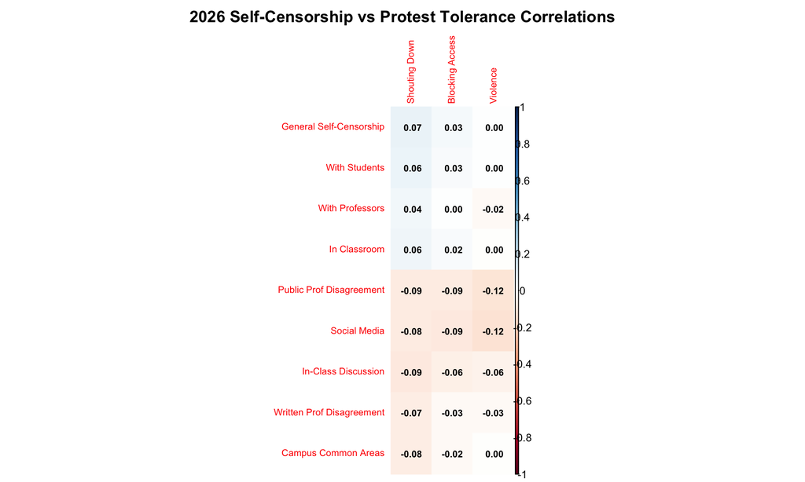

```
##
## 2. ANALYZING IDEOLOGICAL PATTERNS...
## === IDEOLOGICAL PATTERNS IN CAMPUS SPEECH ===
##
## ===  General Self-Censorship  by Political Ideology ===
##                    Df Sum Sq Mean Sq F value Pr(>F)
## ideology_clean     10  13353  1335.3    1191 <2e-16 ***
## Residuals      264262 296367     1.1
## ---
## Signif. codes:  0 '***' 0.001 '**' 0.01 '*' 0.05 '.' 0.1 ' ' 1
## # A tibble: 11 × 4
##    ideology_clean                 N  Mean    SD
##    <ord>                      <int> <dbl> <dbl>
##  1 Very liberal               51200  2.34  1.01
##  2 Somewhat liberal           57450  2.4   0.95
##  3 Slightly liberal           27684  2.52  0.98
##  4 Moderate                   37879  2.64  1.07
##  5 Slightly conservative      16424  2.87  1.11
##  6 Somewhat conservative      21618  2.94  1.18
##  7 Very conservative          13456  3.08  1.28
##  8 Democratic Socialist        6565  2.45  1.08
##  9 Libertarian                 6330  2.74  1.19
## 10 Haven't thought about this 16123  2.41  1.1
## 11 Something else              9544  2.67  1.21
##
## ===  With Students  by Political Ideology ===
##                    Df Sum Sq Mean Sq F value Pr(>F)
## ideology_clean     10   5567   556.7   531.7 <2e-16 ***
## Residuals      182405 190995     1.0
## ---
## Signif. codes:  0 '***' 0.001 '**' 0.01 '*' 0.05 '.' 0.1 ' ' 1
## # A tibble: 11 × 4
##    ideology_clean                 N  Mean    SD
##    <ord>                      <int> <dbl> <dbl>
##  1 Very liberal               32928  2.53  1
##  2 Somewhat liberal           40024  2.65  0.94
##  3 Slightly liberal           19044  2.78  0.95
##  4 Moderate                   26874  2.88  1.03
##  5 Slightly conservative      11470  3.02  1.03
##  6 Somewhat conservative      15576  3.05  1.08
```

[output cut: 149 more lines]

```
##  Abortion :
##
##                                 0    1 <NA>
##   Very liberal               61.5 38.3  0.2
##   Somewhat liberal           56.2 43.6  0.2
##   Slightly liberal           54.8 45.1  0.2
##   Moderate                   51.7 48.1  0.2
##   Slightly conservative      47.5 52.3  0.2
##   Somewhat conservative      41.6 58.2  0.2
##   Very conservative          41.7 58.0  0.2
##   Democratic Socialist       61.5 38.3  0.2
##   Libertarian                54.2 45.5  0.2
##   Haven't thought about this 60.0 39.6  0.4
##   Something else             53.4 46.3  0.2
##   <NA>                       65.1 34.9  0.0
```

```
## Chi-square p-value: < 2.22e-16
##
##  Israel/Palestine :
##
##                                 0    1 <NA>
##   Very liberal               49.0 50.8  0.2
##   Somewhat liberal           52.8 47.0  0.2
##   Slightly liberal           58.6 41.2  0.2
##   Moderate                   63.9 35.9  0.2
##   Slightly conservative      65.4 34.4  0.2
##   Somewhat conservative      66.5 33.4  0.2
##   Very conservative          69.0 30.8  0.2
##   Democratic Socialist       51.8 48.0  0.2
##   Libertarian                69.4 30.4  0.2
##   Haven't thought about this 72.1 27.5  0.4
##   Something else             58.9 40.8  0.2
##   <NA>                       73.8 26.2  0.0
```

```
## Chi-square p-value: < 2.22e-16
##
## Correlations between Topic Difficulty and Self-Censorship:
## Abortion            : r =  0.153, p = < 2.22e-16, N = 263787
## tk_affirmact        : r =  0.157, p = < 2.22e-16, N = 263787
## Gun Control         : r =  0.154, p = < 2.22e-16, N = 263787
## Immigration         : r =  0.177, p = < 2.22e-16, N = 263787
## Israel/Palestine    : r =  0.070, p = < 2.22e-16, N = 263787
## Racial Inequality   : r =  0.186, p = < 2.22e-16, N = 263786
## Transgender Issues  : r =  0.162, p = < 2.22e-16, N = 263787
## tk_sexasslt         : r =  0.108, p = < 2.22e-16, N = 263787
## tk_socmeddplt       : r =  0.193, p = < 2.22e-16, N = 37104
##
## 4. ANALYZING MENTAL HEALTH CORRELATES...
## === MENTAL HEALTH AND SELF-CENSORSHIP CORRELATES ===
##
## ===  Anxiety  Analysis ===
## Sample size: 80287 out of 284372
##
## Correlations with self-censorship:
##   General Self-Censorship  : r =  0.130, p = < 2.22e-16, N = 80286
##   With Students            : r =  0.113, p = < 2.22e-16, N = 80287
##   With Professors          : r =  0.138, p = < 2.22e-16, N = 80286
##   In Classroom             : r =  0.133, p = < 2.22e-16, N = 80287
##
## Correlations with protest tolerance:
##   Shouting Down            : r = -0.064, p = < 2.22e-16, N = 80287
##   Blocking                 : r = -0.018, p = 3.657e-07, N = 80287
##   Violence                 : r =  0.024, p = 5.5346e-12, N = 80287
##
## ===  Loneliness  Analysis ===
## Sample size: 80384 out of 284372
##
## Correlations with self-censorship:
##   General Self-Censorship  : r =  0.182, p = < 2.22e-16, N = 80383
##   With Students            : r =  0.170, p = < 2.22e-16, N = 80384
##   With Professors          : r =  0.164, p = < 2.22e-16, N = 80383
##   In Classroom             : r =  0.167, p = < 2.22e-16, N = 80384
##
## Correlations with protest tolerance:
```

[output cut: 456 more lines]

```
##  Mygender :
##
##                                 No   Yes  <NA>
##   Very liberal                15.0   2.7  82.2
##   Somewhat liberal            13.1   1.6  85.2
##   Slightly liberal            14.6   1.7  83.7
##   Moderate                    13.6   1.3  85.2
##   Slightly conservative       14.3   1.2  84.5
##   Somewhat conservative       13.7   0.6  85.6
##   Very conservative           16.7   0.7  82.6
##   Democratic Socialist        14.4   2.1  83.4
##   Libertarian                 43.5   3.7  52.8
##   Haven't thought about this   0.0   0.0 100.0
##   Something else              18.3   2.4  79.3
##   <NA>                         0.0   0.0 100.0
```

```
## Chi-square p-value: < 2.22e-16
##
## Correlations between Policy Support and Self-Censorship:
## None                     : r = -0.162, p = < 2.22e-16, N = 46597
## Myrace                   : r =  0.008, p = 0.10961, N = 44846
## Notolhate                : r = -0.085, p = < 2.22e-16, N = 44846
## Otherrace                : r = -0.071, p = < 2.22e-16, N = 44846
## Mygender                 : r =  0.021, p = 1.1485e-05, N = 44846
## Othergender              : r =  0.001, p = 0.79749, N = 44846
## Myrelig                  : r =  0.116, p = < 2.22e-16, N = 44846
## Otherrelig               : r = -0.017, p = 0.00025998, N = 44846
##
## 9. ANALYZING POLITICAL ENGAGEMENT...
## === POLITICAL ENGAGEMENT AND ISSUE IMPORTANCE ===
##
## === Issue Importance Patterns ===
## Most important issues to students:
##
##                         <NA>          Environment/Climate
##                         98.6                          0.4
##            Income Inequality Abortion/Reproductive Health
##                          0.2                          0.1
##            Cost of Education                  Immigration
##                          0.1                          0.1
##                   Gun Policy            Racial Inequality
##                          0.1                          0.1
##               Foreign Policy                        Other
##                          0.1                          0.1
##              LGBTQ Treatment
##                          0.0
##
## Issue importance by political ideology:
## Very liberal - Top issues: NA, Environment/Climate, Income Inequality
## Somewhat liberal - Top issues: NA, Environment/Climate, Income Inequality
## Slightly liberal - Top issues: NA, Environment/Climate, Income Inequality
## Moderate - Top issues: NA, Environment/Climate, Cost of Education
## Slightly conservative - Top issues: NA, Environment/Climate, Other
```

```
##
## Chi-square p-value: < 2.22e-16
##
## Self-censorship by most important issue:
##                    Df Sum Sq Mean Sq F value Pr(>F)
## issue_importance    9  119.4  13.271   11.38 <2e-16 ***
## Residuals        2388 2785.7   1.167
## ---
## Signif. codes:  0 '***' 0.001 '**' 0.01 '*' 0.05 '.' 0.1 ' ' 1
## # A tibble: 10 × 4
##    issue_importance                 N Mean_SelfCensor    SD
##    <fct>                        <int>           <dbl> <dbl>
##  1 Foreign Policy                 114            3.16  1.16
##  2 Gun Policy                     142            3.12  1.24
##  3 Other                          181            2.86  1.21
##  4 Abortion/Reproductive Health   208            2.84  1.16
##  5 Immigration                    175            2.84  1.07
##  6 Cost of Education              212            2.55  1.01
##  7 Income Inequality              403            2.55  1.08
##  8 Racial Inequality              174            2.53  1.05
##  9 Environment/Climate            708            2.47  1.01
## 10 LGBTQ Treatment                 81            2.4   0.92
##
## === Voter Registration and Political Engagement ===
## Voter registration distribution:
##
##      0      1   <NA>
##  50634 195814  37924
##
## Voter registration by ideology:
##
##                                 0    1 <NA>
##   Very liberal               10.3 73.1 16.6
##   Somewhat liberal           14.6 72.2 13.2
##   Slightly liberal           18.9 69.2 11.9
##   Moderate                   22.0 66.1 11.8
##   Slightly conservative      20.9 67.6 11.6
##   Somewhat conservative      16.9 71.7 11.4
##   Very conservative          13.0 73.7 13.4
##   Democratic Socialist       19.5 66.1 14.4
```

[output cut: 8 more lines]

```
##
## data:  sc_num by regvoter
## t = 2.2906, df = 72436, p-value = 0.02199
## alternative hypothesis: true difference in means between group 0 and group 1 is not equal to 0
## 95 percent confidence interval:
##  0.001846453 0.023741983
## sample estimates:
## mean in group 0 mean in group 1
##        2.556924        2.544129
##
## # A tibble: 2 × 4
##   regvoter      N Mean_SelfCensor    SD
##      <int>  <int>           <dbl> <dbl>
## 1        0  46457            2.56  1.07
## 2        1 180356            2.54  1.08
```

# Results

## Core Findings: Self-Censorship and Protest Tolerance Relationships

This analysis of 284,372 college students from the 2026 FIRE Campus Speech dataset employed an individual question-level approach to examine relationships between self-censorship behaviors and tolerance for protest tactics. The investigation focused on nine distinct self-censorship contexts and three categories of protest tolerance, providing unprecedented granularity in understanding campus free speech dynamics while testing alliance theory predictions about group-based political preferences.

### Self-Censorship and Protest Tolerance Correlations

The core research question revealed small but statistically significant correlations between specific forms of self-censorship and tolerance for disruptive protest tactics, with patterns varying systematically across different contexts. General self-censorship demonstrated modest positive correlations with tolerance for shouting down speakers (r = 0.070, p < 0.001, N = 264,278) and blocking access to events (r = 0.030, p < 0.001, N = 264,278), while showing no relationship with violence tolerance (r = 0.000, p = 0.879, N = 264,278).

Self-censorship with students showed similar directional patterns with weaker magnitudes (shouting down: r = 0.061, p < 0.001; blocking: r = 0.026, p < 0.001; violence: r = 0.000, p = 0.998, N = 182,419). Self-censorship with professors revealed more complex patterns, showing positive correlations with shouting down (r = 0.044, p < 0.001) but negative correlations with violence tolerance (r = -0.022, p < 0.001, N = 182,418).

## Political Ideology and Expression Patterns

Political ideology emerged as the dominant predictor of both self-censorship behaviors and protest tolerance, with highly significant omnibus effects across all measures. The ideological patterns revealed systematic differences aligned with alliance theory predictions about group-based political preferences.

### Self-Censorship by Political Ideology

Conservative students consistently reported higher levels of self-censorship across all measured contexts (F(10, 264,262) = 1,191, p < 0.001). Very conservative students demonstrated the highest general self-censorship levels (M = 3.08, SD = 1.28), followed by somewhat conservative students (M = 2.94, SD = 1.18) and slightly conservative students (M = 2.87, SD = 1.11). Very liberal students showed the lowest self-censorship (M = 2.34, SD = 1.01), with somewhat liberal students also reporting low levels (M = 2.40, SD = 0.95).

This ideological gradient remained consistent across different social contexts. In classroom settings, very conservative students reported substantially higher self-censorship (M = 3.18, SD = 1.17) compared to very liberal students (M = 2.66, SD = 1.02). Self-censorship with professors showed similar patterns (conservative: M = 3.12, SD = 1.18; liberal: M = 2.65, SD = 1.06), as did self-censorship with other students (conservative: M = 3.05, SD = 1.17; liberal: M = 2.53, SD = 1.00).

## Alliance Theory Validation: Speaker Tolerance and Group Funding

### Speaker Tolerance by Political Content

The analysis provided strong empirical support for alliance theory predictions through examination of speaker tolerance patterns across different political topics. Speaker tolerance varied dramatically based on political content, ranging from 1.48 for speakers advocating racial inferiority to 3.03 for immigration speakers. Transgender-related speakers received among the lowest tolerance (M = 1.88), followed by Black Lives Matter speakers (M = 1.89) and abortion speakers (M = 2.18).

### Group Funding Preferences

Religious group funding showed more balanced patterns across ideological lines, with Christians receiving similar support from liberals (27.5%) and conservatives (24.0%), suggesting that religious affiliation preferences cross-cut political divisions in ways consistent with alliance theory’s emphasis on multiple, potentially competing group identities.

## Topic-Specific Conversation Difficulty and Mental Health Correlates

### Conversation Difficulty Patterns

Topic-specific analysis revealed substantial variation in perceived conversation difficulty across different political issues. Abortion emerged as the most difficult topic for campus conversation, with 45.8% of students reporting difficulty discussing this issue (N = 283,816). Vaccine mandates (43.1%), mask mandates (41.4%), and Israel/Palestine discussions (41.1%) ranked as the next most challenging topics.

Ideological differences in topic difficulty revealed systematic patterns consistent with alliance theory predictions. Conservative students reported greater difficulty discussing abortion (58.0-58.2% for very and somewhat conservative students) compared to liberal students (38.3% for very liberal students). Israel/Palestine discussions showed the inverse pattern, with liberal students reporting substantially greater difficulty (50.8% for very liberal) than conservative students (30.8% for very conservative).

### Mental Health and Campus Speech Behaviors

Mental health indicators revealed significant but complex relationships with campus speech behaviors across four measured domains. Loneliness demonstrated the strongest correlations with self-censorship behaviors, showing positive associations with general self-censorship (r = 0.182, p < 0.001, N = 80,383) and similar patterns across all self-censorship contexts. Loneliness also correlated negatively with all forms of protest tolerance, indicating that socially isolated students both self-censor more and tolerate disruptive protests less.

## Institutional Climate and Administrative Factors

Administrative clarity regarding free speech policies demonstrated strong negative correlations with self-censorship behaviors. Students who perceived greater administrative clarity (M = 3.13, SD = 1.00) reported substantially lower general self-censorship (r = -0.254, p < 0.001, N = 264,277). Administrative defense of speakers showed a similar but weaker negative correlation with self-censorship (r = -0.168, p < 0.001).

Ideological differences in institutional perceptions revealed systematic variation across the political spectrum. Students who had not considered their political ideology reported the highest administrative clarity perceptions (M = 3.28, SD = 1.00), while very conservative students reported the lowest (M = 3.03, SD = 1.14). Liberal students showed intermediate levels (M = 3.13, SD = 1.01), suggesting that institutional climate perceptions vary systematically with political identity.

## Demographic Patterns and Cohort Effects

### Graduation Year Effects

Cohort analysis revealed significant differences in self-censorship behaviors across graduation years (F(7, 264,270) = 393, p < 0.001). Earlier graduation cohorts demonstrated higher self-censorship levels, with 2021 graduates reporting the highest levels (M = 2.72, SD = 1.15) and 2028 graduates showing the lowest (M = 2.32, SD = 1.05). This pattern suggests either generational differences in campus speech experiences or developmental changes in willingness to express controversial views.

### Religious, Gender, and Socioeconomic Patterns

Religious affiliation showed significant associations with self-censorship (F(12, 259,385) = 272.3, p < 0.001), with systematic variation across different religious groups. Gender differences proved statistically significant but practically modest (F(2, 259,345) = 49.89, p < 0.001). Socioeconomic status demonstrated limited practical associations with self-censorship behaviors despite statistical significance (F(4, 224,442) = 42.64, p < 0.001).

Political engagement, measured through voter registration, showed minimal association with self-censorship. Registered voters demonstrated slightly lower self-censorship (M = 2.54, SD = 1.08) compared to non-registered students (M = 2.56, SD = 1.07), though this difference proved statistically significant (t = 2.29, p = 0.022) but practically negligible given the large sample size.

# Discussion

## Alliance Theory and Campus Free Speech Dynamics

The comprehensive analysis of the 2026 FIRE dataset provides substantial empirical validation of alliance theory predictions in the campus free speech context, demonstrating that political expression patterns are fundamentally shaped by group allegiances rather than principled commitments to abstract free speech values. The systematic tolerance gaps between ally and rival speakers across the ideological spectrum directly support core theoretical predictions that political attitudes derive from coalition maintenance rather than moral principles.

The dramatic variation in speaker tolerance based on political content (ranging from 1.48 to 3.03 on tolerance scales) indicates that campus speech attitudes are primarily driven by the political implications of expression rather than procedural commitments to open discourse. The clear ideological gradients in speaker tolerance suggest that campus communities organize around political alliances that systematically favor certain viewpoints while constraining others, contradicting narratives that frame campus free speech conflicts as disputes between pro- and anti-free speech factions.

## The Self-Censorship Paradox Revisited

The positive correlations between certain forms of self-censorship and tolerance for disruptive protest tactics present a theoretical puzzle that challenges conventional free speech frameworks. Traditional liberal theory would predict that individuals committed to open expression would simultaneously oppose censorious tactics by others. Instead, the data reveal a more complex dynamic where self-censorship and tolerance for others’ censorious behaviors may represent complementary strategies within alliance-based political competition.

This pattern aligns with alliance theory’s prediction that apparent contradictions in political beliefs reflect strategic support for different tactics depending on their utility for advancing coalition interests. Students who engage in self-censorship may do so not from principled commitment to civility, but from tactical recognition that their views would be costly to express in current campus environments. Simultaneously, these students may support disruptive tactics when deployed against speakers representing rival coalitions, viewing such tactics as legitimate tools for advancing their side’s political interests.

The contrasting patterns for comfort expressing views provide crucial evidence for this interpretation. Students comfortable publicly disagreeing with professors demonstrated consistently lower tolerance for all protest tactics, suggesting that confidence in expressing disagreement corresponds with preference for orderly discourse rather than disruptive methods. This finding indicates that self-censorship and comfort expressing views capture distinct phenomena rather than opposite poles of the same underlying construct.

## Political Identity as the Primary Driver

The dominance of political ideology as a predictor of both self-censorship and protest tolerance patterns, combined with systematic alliance-based speaker tolerance gaps, provides compelling evidence that campus free speech issues represent political identity conflicts rather than principled debates about expression values. The fact that both conservative and liberal students demonstrate substantial tolerance gaps—favoring allies while opposing rivals—undermines narratives framing campus speech as conflicts between competing philosophical commitments to free expression.

The magnitude of ideological differences in self-censorship (32% higher levels for very conservative compared to very liberal students) suggests meaningful practical differences in perceived freedom to express political views across the ideological spectrum. These asymmetries extend beyond self-censorship to protest tolerance, where liberals demonstrate lower tolerance for disruptive tactics despite reporting lower self-censorship levels. This pattern suggests that campus speech climates may differentially constrain conservative and liberal expression through distinct mechanisms.

## Mental Health and Expression: Reconsidering Causal Relationships

The robust correlations between mental health indicators and campus speech behaviors illuminate previously underexplored dimensions of campus climate research. Loneliness emerged as the strongest predictor of self-censorship behaviors, with correlations suggesting that social isolation may lead to withdrawal from political expression as part of broader patterns of social disengagement. This finding has important implications for understanding the psychological mechanisms underlying campus speech climate effects.

The relationships between stress, depression, and campus speech behaviors challenge simple assumptions about psychological drivers of expression restraint. Rather than psychological distress uniformly leading to behavioral inhibition, these patterns may reflect complex interactions between mental health challenges and social environment characteristics. Students experiencing mental health difficulties may simultaneously seek to avoid additional social conflict through self-censorship while becoming less tolerant of disruptive campus events that create additional stress.

## Institutional Factors and Policy Implications

The strong negative correlation between administrative clarity and self-censorship highlights the crucial role of institutional leadership in shaping campus speech climates. Students who perceive clear administrative positions on free speech policies report substantially lower self-censorship, suggesting that institutional ambiguity may inadvertently encourage speech restriction through uncertainty about consequences and acceptable expression boundaries.

The stronger correlation with administrative clarity compared to administrative defense of speakers indicates that procedural transparency matters more than perceived partisan support for particular viewpoints. This finding suggests that administrative communications emphasizing clear, consistent policies may prove more effective than advocacy for specific speakers or ideological positions, providing a potential pathway for institutional interventions that address speech climate concerns without requiring administrators to navigate complex ideological disputes.

## Limitations and Future Research Directions

Several limitations constrain interpretation of these findings and suggest directions for future investigation. The cross-sectional design prevents causal inferences about relationships between self-censorship and protest tolerance, leaving open questions about whether these attitudes co-develop or whether one influences the other. The individual question approach, while preserving important nuances, may underestimate coherence of underlying attitudes that composite measures would capture.

The self-report nature of the data may introduce social desirability bias, particularly for politically sensitive topics such as tolerance for violence. Additionally, the sample, while large and diverse, comes from students who chose to participate in FIRE surveys and may not represent the full range of campus opinion, potentially undersampling the most politically disengaged students.

Future research should employ longitudinal designs to examine how campus expression attitudes develop over time and in response to specific events or interventions. Experimental studies could test causal mechanisms linking self-censorship to protest tolerance and examine whether interventions targeting one domain affect the other. Cross-institutional comparisons could identify campus-level factors that promote or constrain open expression environments while controlling for student composition effects.

## Broader Implications for Democratic Discourse

These findings extend beyond campus contexts to illuminate fundamental challenges facing democratic discourse in polarized societies. The evidence that expression tolerance is primarily driven by political allegiance rather than principled commitment to free speech suggests that First Amendment protections and liberal democratic norms may be more fragile than commonly assumed. If citizens primarily support expression rights for political allies while seeking to constrain opponents, democratic institutions may face increasing pressure as political polarization intensifies.

The systematic nature of alliance-based tolerance patterns across the ideological spectrum suggests that effective interventions must address fundamental drivers of political polarization rather than focusing solely on symptoms such as campus speaker disruptions or self-censorship behaviors. Understanding campus free speech through an alliance theory lens reveals that debates about expression rights, campus policies, and speaker access are manifestations of deeper conflicts about political power and group status in American society.